# Integrative analysis of metabolome and microbiome

Congcong Gong

```r
library(mbOmic)
```

# Introduction

The `mbOmic` package contains a set of analysis functions for microbiomics and metabolomics data, designed to analyze the inter-omic correlation between microbiology and metabolites, referencing the workflow of Jonathan Braun et al[^1].

```r
# knitr::include_graphics(system.file('extdata', 'intro.png', 'mbOmic'))
```

# Examples

Load metabolites and OTU abundance data of plant.[^2] The OTU had been binned into genera level and were save as the metabolites_and_genera.rda file

```r
path <- system.file('extdata', 'metabolites_and_genera.rda', package = 'mbOmic')

load(path)
```

### Construct `mbSet` object.

```r
names(metabolites)[1] <- 'rn'
m <- mSet(m = metabolites)
m
```

[output not shown]

There are some function to get or set information of a `bSet`, such as `samples` and `features`.

Extract the samples names from `bSet` class by function `Samples`.

```r
samples(m)
```

```
#>  [1] "BS1" "BS2" "BS3" "BS4" "BS5" "BS6" "SS1" "SS2" "SS3" "SS4" "SS5" "SS6"
```

```r
#[1] "BS1" "BS2" "BS3" "BS4" "BS5" "BS6" "SS1" "SS2" "SS3" "SS4" "SS5" "SS6"
```

### Remove bad analytes (OTU and metatoblites)

Removal of analytes only measured in <2 of samples can perform by `clean_analytes`.

```r
m <- clean_analytes(m, fea_num = 2)
```

```
#> 0 features removed:
```

### Generate metabolite module

`mbOmic` can generate metabolite module by `coExpress` function. The `coExpress` function is the encapsulation of one-step network construction and module detection of `WGCNA` package. The `coExpress` function firstly pick up the soft-threshold. The `threshold.d` and `threshold` parameters are used to detect whether is $R^2$ changing and appropriate.

```
#> 0 features removed:
#>
#> One: detect the power for softThreshold
```

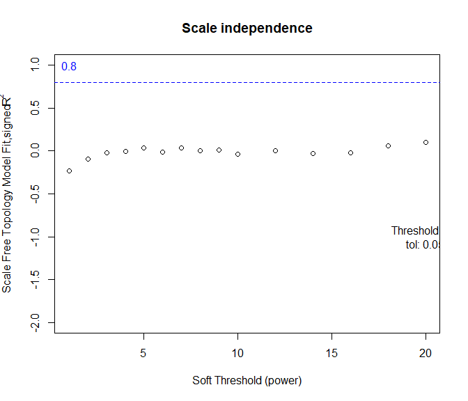

```
#> Error in coExpress(m, message = TRUE, threshold.d = 0.02, threshold = 0.8,  :
#>   No power detected! pls set the power parameter
class(net)
#> [1] "try-error"
```

```r
net <- try({
  coExpress(m,message = TRUE,threshold.d = 0.02, threshold = 0.8, plot = TRUE)
})
```

If you can’t get a good scale-free topology index no matter how high set the soft-thresholding power, you can directly set the power value by the parameter `power`. The appropriate soft-thresholding power can be chosen based on the number of samples as in the table below (recommend by `WGCNA` package).

| **Number of samples** | **Unsigned and signed hybrid networks** | **Signed networks** |
| --- | --- | --- |
| <20 | 9 | 18 |
| 20~30 | 8 | 16 |
| 30~40 | 7 | 14 |
| >40 | 6 | 12 |

```r
net <- coExpress(m,message = TRUE,threshold.d = 0.02, threshold = 0.8, power = 9)
```

```
#> 0 features removed:
#>
#> One: detect the power for softThreshold
#>
#> using the power:  9 to constructe net!
#>
#> Two: Network construction and module detection was done
#> ====> There are  6 modules were constructed:
#> ====||  blue 47
#> ====||  brown 46
#> ====||  green 27
#> ====||  red 22
#> ====||  turquoise 70
#> ====||  yellow 35
```

Result Visualization is performed by function `plot_coExpress`.

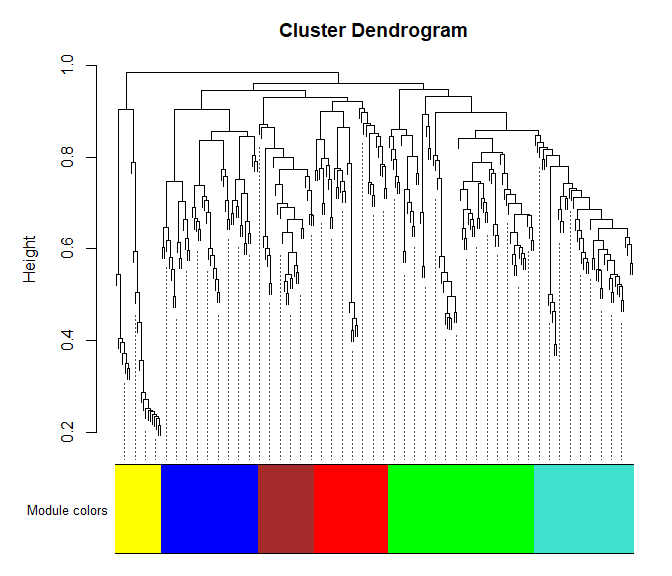

```r
plot_coExpress(net)
```

### Calculate the Spearman metabolite-genera correlation

you can calculate the correlation between metabolites and OTUs by `corr` function. It return a data table containing `rho`, `p value`, and `adjust p value`. Moreover, the `corr` can run in parallel mode.

```r
b <- genera
names(b)[1] <- 'rn'
b <- bSet(b=b)
spearm <- corr(m = m, b = b, method = 'spearman')
# head(spearm)
spearm[p<=0.001]
```

```
#>                                b                                       m
#>   1: unidentified_Acidimicrobiia                             Delavirdine
#>   2:                 Acidibacter          Leucoside 山奈酚3-O-桑布双糖苷
#>   3:                      Dongia          Leucoside 山奈酚3-O-桑布双糖苷
#>   4:  unidentified_Clostridiales          Leucoside 山奈酚3-O-桑布双糖苷
#>   5:                 Acidibacter                           versicotide A
#>  ---
#> 366: unidentified_Acidimicrobiia                        Methyl cinnamate
#> 367:                Chujaibacter                               Catharine
#> 368:                   Ralstonia                               Catharine
#> 369:  unidentified_Clostridiales                               Catharine
#> 370:      Candidatus_Udaeobacter Tri-2,5-cyclohexadien-1-yl(octyl)silane
#>             rho            p        padj
#>   1:  0.8391608 0.0006428260 0.010134767
#>   2: -0.8321678 0.0007854417 0.010744842
#>   3:  0.8601399 0.0003316683 0.008057909
#>   4: -0.8391608 0.0006428260 0.010134767
#>   5: -0.8881119 0.0001141336 0.006342975
#>  ---
#> 366:  0.8671329 0.0002598118 0.007310908
#> 367: -0.8321678 0.0007854417 0.010744842
#> 368: -0.8861660 0.0001239889 0.006526816
#> 369: -0.8881119 0.0001141336 0.006342975
#> 370:  0.8531469 0.0004181179 0.008646290
```

### plot the network

Finally, you can vaisulize the network by `plot_network` function, taking the `coExpress`and `corr` output. The orange nodes correspondes to OTU(genera)).

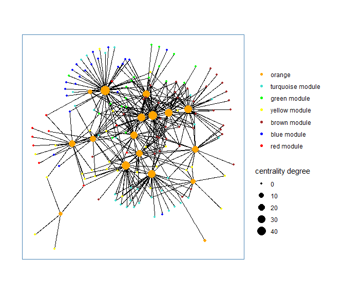

```r
plot_network(net, spearm[abs(rho) >= 0.75 & p <= 0.001], threshold = 0.75, show_text = FALSE)
```

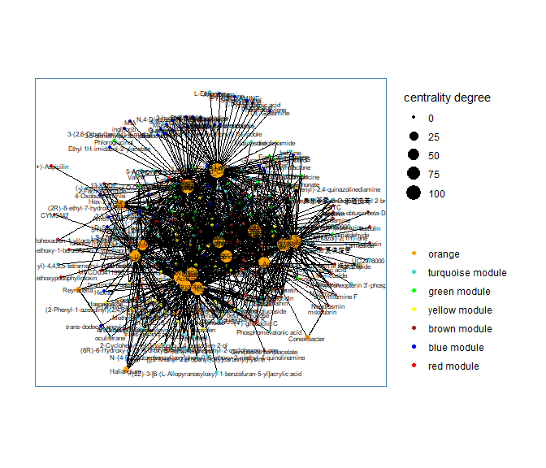

```r
plot_network(net, spearm[abs(rho) >= 0.75 & padj <= 0.05], threshold = 0.75)
```

[^1]: McHardy, I. H., Goudarzi, M., Tong, M., Ruegger, P. M., Schwager, E., Weger, J. R., Graeber, T. G., Sonnenburg, J. L., Horvath, S., Huttenhower, C., McGovern, D. P., Fornace, A. J., Borneman, J., & Braun, J. (2013). Integrative analysis of the microbiome and metabolome of the human intestinal mucosal surface reveals exquisite inter-relationships. *Microbiome*, *1*(1), 17. https://doi.org/10.1186/2049-2618-1-17
[^2]: Huang, W., Sun, D., Chen, L., & An, Y. (2021). Integrative analysis of the microbiome and metabolome in understanding the causes of sugarcane bitterness. Scientific Reports, 11(1), 1-11.